# Midterm_Mkm2203-2

#### 1. Import the spam dataset and print the first six rows.

```python
#import initial libraries
import pandas as pd
import numpy as np
import matplotlib.pyplot as plt
import seaborn as sns
import warnings
warnings.simplefilter(action='ignore', category=FutureWarning)
```

```python
#import spam dataset, using same dataset from different source because it already has the headers, no need for additional cleaning
url = 'https://datahub.io/machine-learning/spambase/r/spambase.csv'
df = pd.read_csv(url)
```

```python
#print first six rows
df.head(6)
```

|  | word_freq_make | word_freq_address | word_freq_all | word_freq_3d | word_freq_our | word_freq_over | word_freq_remove | word_freq_internet | word_freq_order | word_freq_mail | word_freq_receive | word_freq_will | word_freq_people | word_freq_report | word_freq_addresses | word_freq_free | word_freq_business | word_freq_email | word_freq_you | word_freq_credit | word_freq_your | word_freq_font | word_freq_000 | word_freq_money | word_freq_hp | word_freq_hpl | word_freq_george | word_freq_650 | word_freq_lab | … |
| --- | --- | --- | --- | --- | --- | --- | --- | --- | --- | --- | --- | --- | --- | --- | --- | --- | --- | --- | --- | --- | --- | --- | --- | --- | --- | --- | --- | --- | --- | --- |
| 0 | 0.00 | 0.64 | 0.64 | 0.0 | 0.32 | 0.00 | 0.00 | 0.00 | 0.00 | 0.00 | 0.00 | 0.64 | 0.00 | 0.00 | 0.00 | 0.32 | 0.00 | 1.29 | 1.93 | 0.00 | 0.96 | 0.0 | 0.00 | 0.00 | 0.0 | 0.0 | 0.0 | 0.0 | 0.0 | … |
| 1 | 0.21 | 0.28 | 0.50 | 0.0 | 0.14 | 0.28 | 0.21 | 0.07 | 0.00 | 0.94 | 0.21 | 0.79 | 0.65 | 0.21 | 0.14 | 0.14 | 0.07 | 0.28 | 3.47 | 0.00 | 1.59 | 0.0 | 0.43 | 0.43 | 0.0 | 0.0 | 0.0 | 0.0 | 0.0 | … |
| 2 | 0.06 | 0.00 | 0.71 | 0.0 | 1.23 | 0.19 | 0.19 | 0.12 | 0.64 | 0.25 | 0.38 | 0.45 | 0.12 | 0.00 | 1.75 | 0.06 | 0.06 | 1.03 | 1.36 | 0.32 | 0.51 | 0.0 | 1.16 | 0.06 | 0.0 | 0.0 | 0.0 | 0.0 | 0.0 | … |
| 3 | 0.00 | 0.00 | 0.00 | 0.0 | 0.63 | 0.00 | 0.31 | 0.63 | 0.31 | 0.63 | 0.31 | 0.31 | 0.31 | 0.00 | 0.00 | 0.31 | 0.00 | 0.00 | 3.18 | 0.00 | 0.31 | 0.0 | 0.00 | 0.00 | 0.0 | 0.0 | 0.0 | 0.0 | 0.0 | … |
| 4 | 0.00 | 0.00 | 0.00 | 0.0 | 0.63 | 0.00 | 0.31 | 0.63 | 0.31 | 0.63 | 0.31 | 0.31 | 0.31 | 0.00 | 0.00 | 0.31 | 0.00 | 0.00 | 3.18 | 0.00 | 0.31 | 0.0 | 0.00 | 0.00 | 0.0 | 0.0 | 0.0 | 0.0 | 0.0 | … |
| 5 | 0.00 | 0.00 | 0.00 | 0.0 | 1.85 | 0.00 | 0.00 | 1.85 | 0.00 | 0.00 | 0.00 | 0.00 | 0.00 | 0.00 | 0.00 | 0.00 | 0.00 | 0.00 | 0.00 | 0.00 | 0.00 | 0.0 | 0.00 | 0.00 | 0.0 | 0.0 | 0.0 | 0.0 | 0.0 | … |

#### 2. Read through the documentation of the original dataset here:

http://archive.ics.uci.edu/ml/machine-learning-databases/spambase/spambase.names

##### The dependent variable is "spam" where one indicates that an email is spam and zero otherwise. Which three variables in the dataset do you think will be important predictors in a model of spam? Why?

I think the following variables will help predict model of spam:

word_freq_order - Spam emails tend to have to do with ordering or buying something, so if order occurs frequently it's more likely to be spam.

word_freq_project - Project is a word often used in non-spam emails, usually in colleague to colleague emails. If an email is frequently mentioning project it's likely negatively correlated with spam.

word_freq_credit - similar to order, spam emails might try to scam you with credit threats or get you to buy something using credit, so if it's mentioned often it's more likely spam.

#### 3. Visualize the univariate distribution of each of the variables in the previous question.

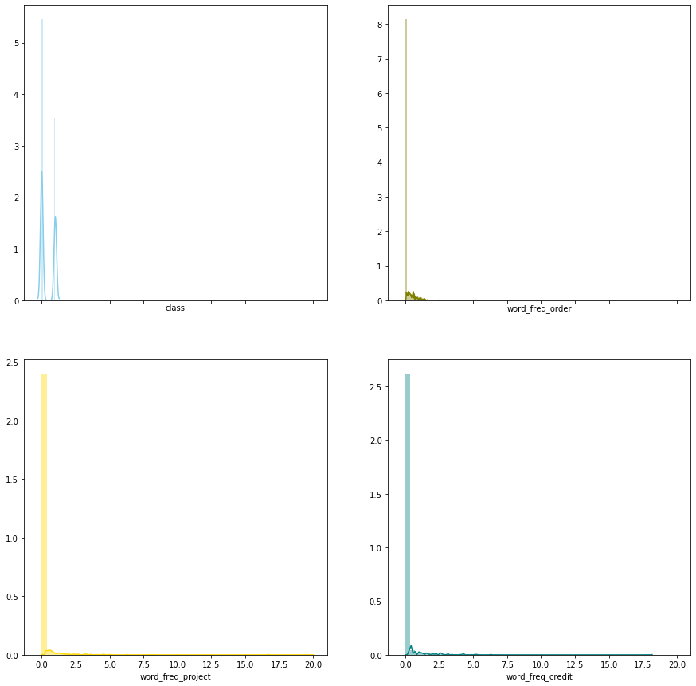

```python
# plot univariate distributions of variables
f, axes = plt.subplots(2, 2, figsize=(15, 15), sharex=True)
sns.distplot( df["class"] , color="skyblue", ax=axes[0, 0])
sns.distplot( df["word_freq_order"] , color="olive", ax=axes[0, 1])
sns.distplot( df["word_freq_project"] , color="gold", ax=axes[1, 0])
sns.distplot( df["word_freq_credit"] , color="teal", ax=axes[1, 1])
```

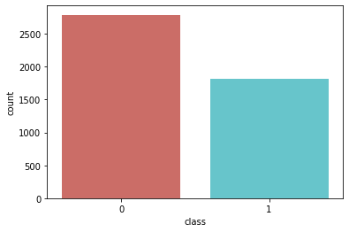

```python
#examine target variable to see if there's enough represenatation of each to make a model (extra, not assigned)
sns.countplot(x='class', data=df,palette='hls')
plt.show()
```

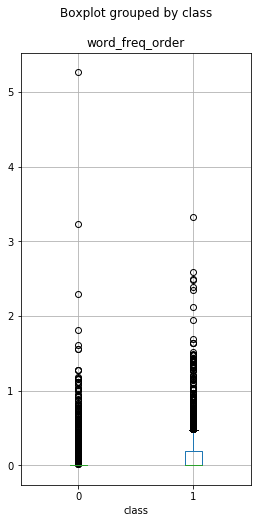

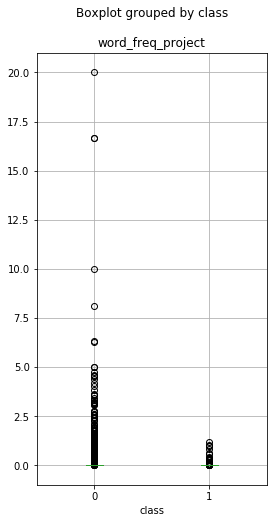

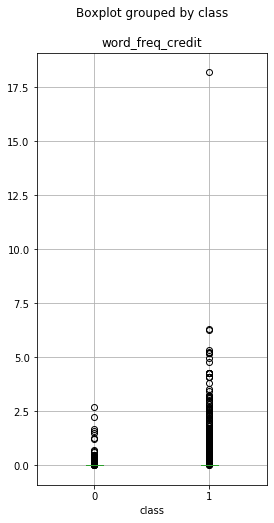

```python
#plot of each variable within each class (extra, not assigned)
df.boxplot(column="word_freq_order",
          by = "class",
          figsize=(4,8))
df.boxplot(column="word_freq_project",
          by = "class",
          figsize=(4,8))
df.boxplot(column="word_freq_credit",
          by = "class",
          figsize=(4,8))
```

#### 4. Name each of the supervised learning models that we have learned thus far that are used to predict dependent variables like "spam". (Include models we have learned through class 6 only).

Models that are used to predict spam are Supervised Classification Models. So far we have learned about these classification models:

1) Logistic Regression

2) Decision Trees and Ensembles of Decision Trees (Random Forests Classifier, Bagging, Gradient Boosting)

3) KNN - K Nearest Neighbor (classifier)

4) SVM (Support Vector Machines) implemented as Linear SVC

#### 5. Describe the importance of training and test data. Why do we separate data into these subsets?

It is important to split the data into training and test subsets so we can make sure the model can be generalized to new data and maintain accuracy. It helps us understand if the model is overfitting to the data (the accuracy of the training set is higher than the test set) or underfitting to the data (the accuracy of the test set is higher than the training set).

#### 6. What is k-fold cross validation and what do we use it for?

Cross Validation is a way to evaluate the generalization performance by spliting the data repeatedly in different ways, so multiple models are trained.

Without CV, training and test sets can be split arbitrarily and you can either get strong or poor results on the same data based on where it was cut. CV allows it to be cut in multiple ways so you can make sure your model is not picking up on too much bias or variance.

K fold CV is a method of cross validation where k is the number of splits determined by the user in an argument. Usually this number is 5 or 10. Example, if it is 5, then the data is partitioned into 5 parts, or folds, of approximately equal size. The model is trained on the first fold of training and test, then the second, etc. It is repeated on each of the 5 splits. It produces the accuracy of all 5 splits so we can better understand the performance of the model.

#### 7. How is k-fold cross validation different from stratified k-fold cross validation?

K fold doesn't account for classification datasets, so if you use it on a dataset with a classification target variable it doesn't account for the distribution of each class in the folds.

In stratified CV the data is split in a way that the proportion of the classes in the target are the same in each fold, so that it trains the models better for classification models. It gives more reliable estimates of genralization performance.

#### 8. Choose one model from question four. Split the data into training and test subsets. Build a model with the three variables in the dataset that you think will be good predictors of "spam". Describe why you chose any particular parameters for your model (e.g.- if you used KNN how did you decide to choose a specific value for k). Run the model and evaluate prediction error in two ways: A) On test data directly and B) using k-fold cross-validation.

## Logistic Regression

I chose to first try logisitc regression without scalers because I think the data is scaled already since the variables are in frequencies. However, after performing the first logistic regression I wanted to try it with a L1 penatly and then with the scalers.

```python
#import scikit learn packages
from sklearn.model_selection import train_test_split
from sklearn.model_selection import RepeatedKFold
from sklearn.model_selection import StratifiedKFold
from sklearn.model_selection import KFold
from sklearn.model_selection import cross_val_score
from sklearn.linear_model import LogisticRegression
```

```python
# split to train test data, include only 3 variables in X
y = df['class']
X = df.loc[:, ['word_freq_order', 'word_freq_project', 'word_freq_credit']]

X_train, X_test, y_train, y_test = train_test_split(X, y, random_state=42)
```

```python
#fit the logistic regression model
logreg = LogisticRegression().fit(X_train, y_train)

print("LOGISTIC REGRESSION (UNSCALED DATA)")
print("Training set score: {:.2f}".format(logreg.score(X_train, y_train)))
print("Test set score: {:.2f}".format(logreg.score(X_test, y_test)))
```

```
LOGISTIC REGRESSION (UNSCALED DATA)
Training set score: 0.70
Test set score: 0.68
```

```python
#penalized LogReg
pen_logreg = LogisticRegression(penalty = 'l1').fit(X_train, y_train) # Default = L2, Penalty = L1

print("PENALIZED LOGISTIC REGRESSION (UNSCALED DATA)")
print("Training set score: {:.2f}".format(pen_logreg.score(X_train, y_train)))
print("Test set score: {:.2f}".format(pen_logreg.score(X_test, y_test)))
```

```
PENALIZED LOGISTIC REGRESSION (UNSCALED DATA)
Training set score: 0.70
Test set score: 0.68
```

```python
# add standard scalers
from sklearn import preprocessing
scaler = preprocessing.StandardScaler().fit(X_train)
X_train_scaled = scaler.transform(X_train)
X_test_scaled = scaler.transform(X_test)
```

```python
#logreg with standard scaler
logreg = LogisticRegression().fit(X_train_scaled, y_train)

print("LOGISTIC REGRESSION (SCALED DATA)")
print("Training set score: {:.2f}".format(logreg.score(X_train_scaled, y_train)))
print("Test set score: {:.2f}".format(logreg.score(X_test_scaled, y_test)))
```

```
LOGISTIC REGRESSION (SCALED DATA)
Training set score: 0.70
Test set score: 0.68
```

```python
#define kfold with 5 splits
kfold = KFold(n_splits=5)

# Kfold Cross Validation
print("KFold:\n{}".format(
cross_val_score(logreg, X_train, y_train, cv=kfold)))
cvmeanlog = np.mean(cross_val_score(logreg, X_train, y_train, cv=kfold))
print("Cross-validation mean: " + str(cvmeanlog))

# Spam prediction from test set
logreg_predicted_vals = logreg.predict(X_test)

# Organize the model coefficients
logreg_coef = pd.DataFrame(data=logreg.coef_, columns=X.columns, index=['Logistic Regression Coefficients'])
logreg_coef.head()
```

```
KFold:
[0.68985507 0.70289855 0.67971014 0.72318841 0.6942029 ]
Cross-validation mean: 0.6979710144927537
```

|  | word_freq_order | word_freq_project | word_freq_credit |
| --- | --- | --- | --- |
| Logistic Regression Coefficients | 0.490727 | -2.606225 | 1.968689 |

As expected, the standard scaler did not improve the model. Neither did the penalized logistic regression.

The KFold CV shows that there is not a lot of variance between different splits of the training data. The model performs well on all of them and the mean of CV is a little higher than the test set score, showing the results are reliable on different cuts of the data.

#### 9. Choose a second model from question four. Using the same three variables in the dataset that you think will be good predictors of "spam". Describe why you chose any particular parameters for your model (e.g.- if you used KNN how did you decide to choose a specific value for k). Run the model and evaluate prediction error in two ways: A) On test data directly and B) using k-fold cross-validation. Did this model predict test data better than your previous model?

## KNN

In the KNN models, I chose to use n=5 and n=10, since those are standard splits of neighbors in the data. Since the standard scaler made little difference. I also chose the KNN Classifier instead of the Regressor because I thought the majority vote method would work better with the classification data.

```python
#K nearest neighbors, n=5
from sklearn.neighbors import KNeighborsClassifier

knn = KNeighborsClassifier(n_neighbors=5)
knn.fit(X_train, y_train)

#Print accuracy rounded to two digits to the right of decimal
print("accuracy: {:.2f}".format(knn.score(X_train, y_train)))
print("accuracy: {:.2f}".format(knn.score(X_test, y_test)))


y_pred = knn.predict(X_test) # y_pred includes your predictions
```

```
accuracy: 0.72
accuracy: 0.69
```

```python
#K nearest neighbors, n=10
knn = KNeighborsClassifier(n_neighbors=10)
knn.fit(X_train, y_train)

#Print accuracy rounded to two digits to the right of decimal
print("accuracy: {:.2f}".format(knn.score(X_train, y_train)))
print("accuracy: {:.2f}".format(knn.score(X_test, y_test)))


y_pred = knn.predict(X_test) # y_pred includes your predictions
```

```
accuracy: 0.72
accuracy: 0.70
```

```python
#kfold cross validation
print("KFold:\n{}".format(
cross_val_score(knn, X_train, y_train, cv=kfold)))

cvmeanknn = np.mean(cross_val_score(knn, X_train, y_train, cv=kfold))
print("Cross-validation mean: " + str(cvmeanknn))
```

```
KFold:
[0.69710145 0.72173913 0.68985507 0.73188406 0.43913043]
Cross-validation mean: 0.6559420289855072
```

The model with 10 neighbors performed slightly better on the test set than the model with 5 neighbors, though they performed equally on the training data. The CV mean is lower than the logistic regression set. I can see that it performed similarly in the first 4 cuts, but really dropped on the last cut.

#### 10. Choose a third model from question four. Using the same three variables in the dataset that you think will be good predictors of "spam". Describe why you chose any particular parameters for your model (e.g.- if you used KNN how did you decide to choose a specific value for k). Run the model and evaluate prediction error in two ways: A) On test data directly and B) using k-fold cross-validation. Did this model predict test data better than your previous models?

## Random Forest

```python
from sklearn.tree import DecisionTreeRegressor
from sklearn.ensemble import BaggingRegressor
from sklearn.ensemble import RandomForestClassifier
```

```python
#random forest with 100 estimators
forest = RandomForestClassifier(bootstrap=True, n_estimators=100)
forest.fit(X_train, y_train)
ypred = forest.predict(X_test)
```

```python
#accuracy w/o CV
print("Accuracy on training set: {:.3f}".format(forest.score(X_train, y_train)))
print("Accuracy on test set: {:.3f}".format(forest.score(X_test, y_test)))
```

```
Accuracy on training set: 0.735
Accuracy on test set: 0.685
```

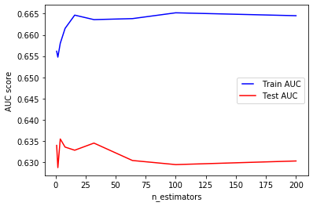

```python
#using AUC score to decide N estimators
from sklearn.metrics import roc_curve, auc
n_estimators = [1, 2, 4, 8, 16, 32, 64, 100, 200]
train_results = []
test_results = []
for estimator in n_estimators:
   rf = RandomForestClassifier(n_estimators=estimator, n_jobs=-1)
   rf.fit(X_train, y_train)
   train_pred = rf.predict(X_train)
   false_positive_rate, true_positive_rate, thresholds = roc_curve(y_train, train_pred)
   roc_auc = auc(false_positive_rate, true_positive_rate)
   train_results.append(roc_auc)
   y_pred = rf.predict(X_test)
   false_positive_rate, true_positive_rate, thresholds = roc_curve(y_test, y_pred)
   roc_auc = auc(false_positive_rate, true_positive_rate)
   test_results.append(roc_auc)
from matplotlib.legend_handler import HandlerLine2D
line1, = plt.plot(n_estimators, train_results, 'b', label= "Train AUC")
line2, = plt.plot(n_estimators, test_results, 'r', label="Test AUC")
plt.legend(handler_map={line1: HandlerLine2D(numpoints=2)})
plt.ylabel('AUC score')
plt.xlabel('n_estimators')
plt.show()
```

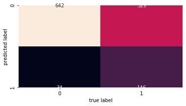

```python
#confusion matrix
from sklearn.metrics import confusion_matrix
mat = confusion_matrix(y_test, ypred)
sns.heatmap(mat.T, square=True, annot=True, fmt='d', cbar=False)
plt.xlabel('true label')
plt.ylabel('predicted label');
```

```python
#additional performance metrics of random forest model
from sklearn.metrics import accuracy_score,recall_score,precision_score,f1_score
print('Accuracy Score : ' + str(accuracy_score(y_test,y_pred)))
print('Precision Score : ' + str(precision_score(y_test,y_pred)))
print('Recall Score : ' + str(recall_score(y_test,y_pred)))
print('F1 Score : ' + str(f1_score(y_test,y_pred)))
```

```
Accuracy Score : 0.6863596872284969
Precision Score : 0.8166666666666667
Recall Score : 0.3094736842105263
F1 Score : 0.44885496183206103
```

```python
#kfold cross validation
print("KFold:\n{}".format(
cross_val_score(forest, X_train, y_train, cv=kfold)))

cvmeanrf = np.mean(cross_val_score(forest, X_train, y_train, cv=kfold))
print("Cross-validation mean: " + str(cvmeanrf))
```

```
KFold:
[0.69565217 0.70869565 0.6942029  0.73043478 0.69130435]
Cross-validation mean: 0.7023188405797101
```

The Random Forest performed with the most accuracy on the training data, but about the same as the other models on the test set. It is the most overfit model of the previous ones used. However, CV reveals it is fairly consistent across different splits of the data, unlike KNN where one partition perfromed very poorly.

#### 11. Choose a fourth model from question four. Using the same three variables in the dataset that you think will be good predictors of "spam". Describe why you chose any particular parameters for your model (e.g.- if you used KNN how did you decide to choose a specific value for k). Run the model and evaluate prediction error in two ways: A) On test data directly and B) using k-fold cross-validation. Did this model predict test data better than your previous models?

## SVM

For the Support Vector Machine, I selected the gamma and C values through simple Grid Search and adjusted the values according to the results, which was 10 for gamma and for C.

```python
#SVC from SVM
from sklearn.svm import SVC
svc = SVC(gamma=10, C=10)
svc.fit(X_train, y_train)
print("Accuracy on training set: {:.2f}".format(svc.score(X_train, y_train)))
print("Accuracy on test set: {:.2f}".format(svc.score(X_test, y_test)))

print("KFold:\n{}".format(
cross_val_score(svc, X_train, y_train, cv=kfold)))

cvmeansvm = np.mean(cross_val_score(svc, X_train, y_train, cv=kfold))
print("Cross-validation mean: " + str(cvmeansvm))
```

```
Accuracy on training set: 0.72
Accuracy on test set: 0.69
KFold:
[0.69710145 0.70869565 0.70144928 0.72608696 0.70144928]
Cross-validation mean: 0.7069565217391305
```

```python
#gridserach to decide best c and gamma
print("Size of training set: {} size of test set: {}".format(
               X_train.shape[0], X_test.shape[0]))
best_score = 0
for gamma in [0.001, 0.01, 0.1, 1, 10, 100]:
  for C in [0.001, 0.01, 0.1, 1, 10, 100]:
    # for each combination of parameters, train an SVC
    svm = SVC(gamma=gamma, C=C)
    svm.fit(X_train, y_train)
    # evaluate the SVC on the test set
    score = svm.score(X_test, y_test)
    # if we got a better score, store the score and parameters
    if score > best_score:
      best_score = score
      best_parameters = {'C': C, 'gamma': gamma}
print("Best score: {:.2f}".format(best_score))
print("Best parameters: {}".format(best_parameters))
```

```
Size of training set: 3450 size of test set: 1151
Best score: 0.69
Best parameters: {'C': 10, 'gamma': 10}
```

## Comparision of Models

```python
#scores from above printed for easy comparison
print("Logistic Regression")
print("Training set score: {:.2f}".format(logreg.score(X_train, y_train)))
print("Test set score: {:.2f}".format(logreg.score(X_test, y_test)))

print("Cross-validation mean: " + str(cvmeanlog))
print("")
print("KNN ")
print("Training set score: {:.2f}".format(knn.score(X_train, y_train)))
print("Test set score: {:.2f}".format(knn.score(X_test, y_test)))
print("Cross-validation mean: " + str(cvmeanknn))
print("")
print("Random Forest")
print("Training set score: {:.3f}".format(forest.score(X_train, y_train)))
print("Test set score: {:.3f}".format(forest.score(X_test, y_test)))
print("Cross-validation mean: " + str(cvmeanrf))
print("")
print("SVM")
print("Training set score: {:.2f}".format(svc.score(X_train, y_train)))
print("Test set score: {:.2f}".format(svc.score(X_test, y_test)))
print("Cross-validation mean: " + str(cvmeansvm))
```

```
Logistic Regression
Training set score: 0.67
Test set score: 0.66
Cross-validation mean: 0.6979710144927537

KNN
Training set score: 0.72
Test set score: 0.70
Cross-validation mean: 0.6559420289855072

Random Forest
Training set score: 0.735
Test set score: 0.685
Cross-validation mean: 0.7023188405797101

SVM
Training set score: 0.72
Test set score: 0.69
Cross-validation mean: 0.7069565217391305
```

#### 12. Now rerun your best model from questions 8 through 11, but this time add three new variables to the model that you think will increase prediction accuracy. Did this model predict test data better than your previous models?

## Feature Selection w/ RFE

I decided to select the next three variables through RFE and found that word_freq_remove, word_freq_george, and char*freq*%24 are important predictors according to the results. If I were to select the 6 again, I'd use this to choose all of them.

```python
#Feature Selection through Recursive Feature Elimination
from sklearn.feature_selection import RFE

y = df['class'] # assign outcome variable, i.e. what we want to predict
X = df.loc[:, df.columns != 'class'] # assign all other values as X-values, i.e. variables we use to predict

X_train, X_test, y_train, y_test = train_test_split(X, y, random_state=42)
# randomly assign some data to the test-set and the rest to the training-set

X.head()

model = LogisticRegression()
rfe = RFE(model,3)
fit = rfe.fit(X_train, y_train)
print("Num Features: %s" % (fit.n_features_))
print("Selected Features: %s" % (fit.support_))
print("Feature Ranking: %s" % (fit.ranking_))
```

```
Num Features: 3
Selected Features: [False False False False False False  True False False False False False
 False False False False False False False False False False False False
 False False  True False False False False False False False False False
 False False False False False False False False False False False False
 False False False False  True False False False False]
Feature Ranking: [36 44 41 20 24 21  1 31 16 47 35 48 49 45  6 14 13 43 50  4 37 39  2 26
  5 17  1 34 12 29 51 46 22 32 19 23 53 27 15 42 11 10 25  3 30  8 18  7
 28 40 33 38  1  9 52 54 55]
```

```python
#new data with 3 added variables to original set
y = df['class']
X = df.iloc[:, [6,8,19,26,43,52]]

X_train, X_test, y_train, y_test = train_test_split(X, y, random_state=42)
```

## KNN with New Variables

```python
knn = KNeighborsClassifier(n_neighbors=10)
knn.fit(X_train, y_train)

#Print accuracy rounded to two digits to the right of decimal
print("accuracy: {:.2f}".format(knn.score(X_train, y_train)))
print("accuracy: {:.2f}".format(knn.score(X_test, y_test)))

print("KFold:\n{}".format(
cross_val_score(knn, X_train, y_train, cv=kfold)))

cvmeanknn = np.mean(cross_val_score(knn, X_train, y_train, cv=kfold))
print("Cross-validation mean: " + str(cvmeanknn))
```

```
accuracy: 0.87
accuracy: 0.85
KFold:
[0.84782609 0.85217391 0.85942029 0.88405797 0.88115942]
Cross-validation mean: 0.8649275362318841
```

This model did predict much better with the new variables than the previous model.

#### 13. Rerun all your other models with this final set of six variables, evaluate prediction error, and choose a final model. Why did you select this model among all of the models that you ran?

## Random Forest with New Variables

```python
forest = RandomForestClassifier(n_estimators=50)
forest.fit(X_train, y_train)
ypred = forest.predict(X_test)
```

```python
print("Accuracy on training set: {:.3f}".format(forest.score(X_train, y_train)))
print("Accuracy on test set: {:.3f}".format(forest.score(X_test, y_test)))
print("KFold:\n{}".format(
cross_val_score(forest, X_train, y_train, cv=kfold)))

cvmeanrf = np.mean(cross_val_score(forest, X_train, y_train, cv=kfold))
print("Cross-validation mean: " + str(cvmeanrf))
```

```
Accuracy on training set: 0.904
Accuracy on test set: 0.853
KFold:
[0.85507246 0.85652174 0.84347826 0.88695652 0.87536232]
Cross-validation mean: 0.8631884057971014
```

```python
print('Accuracy Score : ' + str(accuracy_score(y_test,y_pred)))
print('Precision Score : ' + str(precision_score(y_test,y_pred)))
print('Recall Score : ' + str(recall_score(y_test,y_pred)))
print('F1 Score : ' + str(f1_score(y_test,y_pred)))
```

```
Accuracy Score : 0.6863596872284969
Precision Score : 0.8166666666666667
Recall Score : 0.3094736842105263
F1 Score : 0.44885496183206103
```

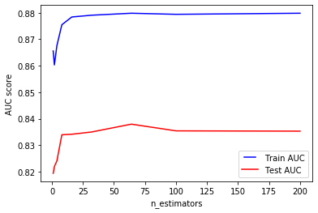

```python
from sklearn.metrics import roc_curve, auc
n_estimators = [1, 2, 4, 8, 16, 32, 64, 100, 200]
train_results = []
test_results = []
for estimator in n_estimators:
   rf = RandomForestClassifier(n_estimators=estimator, n_jobs=-1)
   rf.fit(X_train, y_train)
   train_pred = rf.predict(X_train)
   false_positive_rate, true_positive_rate, thresholds = roc_curve(y_train, train_pred)
   roc_auc = auc(false_positive_rate, true_positive_rate)
   train_results.append(roc_auc)
   y_pred = rf.predict(X_test)
   false_positive_rate, true_positive_rate, thresholds = roc_curve(y_test, y_pred)
   roc_auc = auc(false_positive_rate, true_positive_rate)
   test_results.append(roc_auc)
from matplotlib.legend_handler import HandlerLine2D
line1, = plt.plot(n_estimators, train_results, 'b', label= "Train AUC")
line2, = plt.plot(n_estimators, test_results, 'r', label="Test AUC")
plt.legend(handler_map={line1: HandlerLine2D(numpoints=2)})
plt.ylabel('AUC score')
plt.xlabel('n_estimators')
plt.show()
```

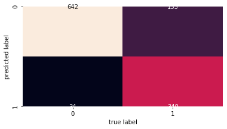

```python
from sklearn.metrics import confusion_matrix
mat = confusion_matrix(y_test, ypred)
sns.heatmap(mat.T, square=True, annot=True, fmt='d', cbar=False)
plt.xlabel('true label')
plt.ylabel('predicted label');
```

## Logistic Regression with New Variables

```python
logreg = LogisticRegression().fit(X_train, y_train)

print("LOGISTIC REGRESSION")
print("Training set score: {:.2f}".format(logreg.score(X_train, y_train)))
print("Test set score: {:.2f}".format(logreg.score(X_test, y_test)))

# Kfold Cross Validation
print("KFold:\n{}".format(
cross_val_score(logreg, X_train, y_train, cv=kfold)))
print("Mean Cross Validation, KFold: {:.2f}".format(np.mean(cross_val_score(logreg, X_train, y_train, cv=kfold))))
```

```
LOGISTIC REGRESSION
Training set score: 0.86
Test set score: 0.84
KFold:
[0.84202899 0.83623188 0.84492754 0.87246377 0.87536232]
Mean Cross Validation, KFold: 0.85
```

## SVM with New Variables

```python
svc = SVC(gamma=10,C=1)
svc.fit(X_train, y_train)
print("Accuracy on training set: {:.2f}".format(svc.score(X_train, y_train)))
print("Accuracy on test set: {:.2f}".format(svc.score(X_test, y_test)))

print("KFold:\n{}".format(
cross_val_score(svc, X_train, y_train, cv=kfold)))

cvmeansvm = np.mean(cross_val_score(svc, X_train, y_train, cv=kfold))
print("Cross-validation mean: " + str(cvmeansvm))
```

```
Accuracy on training set: 0.87
Accuracy on test set: 0.85
KFold:
[0.85942029 0.84927536 0.85507246 0.87681159 0.8826087 ]
Cross-validation mean: 0.8646376811594202
```

```python
print("Size of training set: {} size of test set: {}".format(
               X_train.shape[0], X_test.shape[0]))
best_score = 0
for gamma in [0.001, 0.01, 0.1, 1, 10, 100]:
  for C in [0.001, 0.01, 0.1, 1, 10, 100]:
    # for each combination of parameters, train an SVC
    svm = SVC(gamma=gamma, C=C)
    svm.fit(X_train, y_train)
    # evaluate the SVC on the test set
    score = svm.score(X_test, y_test)
    # if we got a better score, store the score and parameters
    if score > best_score:
      best_score = score
      best_parameters = {'C': C, 'gamma': gamma}
print("Best score: {:.2f}".format(best_score))
print("Best parameters: {}".format(best_parameters))
```

```
Size of training set: 3450 size of test set: 1151
Best score: 0.85
Best parameters: {'C': 1, 'gamma': 10}
```

```python
print("Logistic Regression")
print("Training set score: {:.2f}".format(logreg.score(X_train, y_train)))
print("Test set score: {:.2f}".format(logreg.score(X_test, y_test)))
print("Cross-validation mean: {:.2f}".format(np.mean(cross_val_score(logreg, X_train, y_train, cv=kfold))))
print("")
print("KNN ")
print("Training set score: {:.2f}".format(knn.score(X_train, y_train)))
print("Test set score: {:.2f}".format(knn.score(X_test, y_test)))
print("Cross-validation mean: " + str(cvmeanknn))
print("")
print("Random Forest")
print("Training set score: {:.3f}".format(forest.score(X_train, y_train)))
print("Test set score: {:.3f}".format(forest.score(X_test, y_test)))
print("Cross-validation mean: " + str(cvmeanrf))
print("")
print("SVM")
print("Training set score: {:.2f}".format(svc.score(X_train, y_train)))
print("Test set score: {:.2f}".format(svc.score(X_test, y_test)))
print("Cross-validation mean: " + str(cvmeansvm))
```

```
Logistic Regression
Training set score: 0.86
Test set score: 0.84
Cross-validation mean: 0.85

KNN
Training set score: 0.87
Test set score: 0.85
Cross-validation mean: 0.8649275362318841

Random Forest
Training set score: 0.904
Test set score: 0.853
Cross-validation mean: 0.8631884057971014

SVM
Training set score: 0.87
Test set score: 0.85
Cross-validation mean: 0.8646376811594202
```

All the models performed better with the added variables. KNN and SVM performed very similarly, but KNN is still the best model because the CV mean is slightly higher. It is also takes less time and power to run, so I would choose KNN as the best classifier out of the four.

#### 14. What variable that currently is not in your model, if included, would be likely to increase your final model's predictive power? For this answer try to speculate about a variable outside the variables available in the data that would improve you model.

If we could determine number of recipients of the email, it might better classify spam. In addition, a variable showing the number of times, or percentage if possible, a recipient has deleted unopened emails from the sender's address can also help determine if it is spam.

##### 15. Lastly, you have listed each of the models that we have learned to use to predict dependent variables like spam. List each model we have focused on in class thus far that you could use to evaluate data with a continuous dependent variable. (Include models we have learned through class 6 only).

Some of the models we used for classification can be used for continuous variables, but with a slightly different technique.

1) Logistic Regression (OLS, ridge and lasso)

2) Decision Trees and Ensembles of Regressor Decision Trees (Random Forests, Bagging, Boosting)

3) K Nearest Neighbors (Regression, not Classifier)

4) Support Vector Regression (Similar to SVM, but for regression)